# Bumblebee Lab 11

Manasi Raol, William Brickowski, Rachael Robinson, Brady Kiesling

4/3/2019

#Lab 11

##Individual Plots of Your Name’s popularity over time

###Rachael

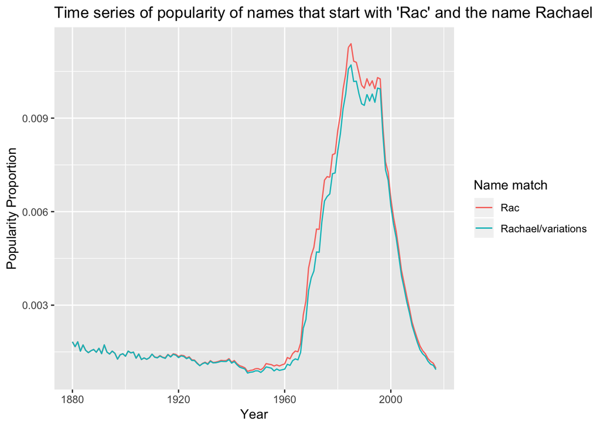

The regular expression I used to match the variations of my name in the data set was “^R[eay]+ch[ae]+l$”.

I was born in the year 1998. According to the graph, this looks like the end of the peak popularity for the name “Rachael” and it’s variations. In 1998, “Rachael” and it’s variations had a popularity proportion of about 0.0095. After the year 2000, the graph shows a sharp decline in the popularity of my name, approaching a popularity proportion of about 0.001. Thus, my name is significantly less popular now than it was when I was born.

The graph shows a strong relationship between names that start with “Rac” and “Rachael”, indicating that it is rare for a name to start with the letters “Rac” and not end up being “Rachael” or a variation. This is corroborated by observation in the data set. Due to this relationship, names that start with “Rac” and the name “Rachael” are approximately equal in popularity now, according to the graph.

###Manasi

library(tidyverse) library(babynames) baby <- babynames::babynames

baby1 <- baby %>% filter(str_detect(name, “^Man”)) %>% group_by(year) %>% mutate(totalprop = sum(prop))

baby2 <- baby %>% filter(str_detect(name, “^Man[a]+s[ei]$”)) %>% group_by(year) %>% mutate(totalprop = sum(prop))

###Brady

###William

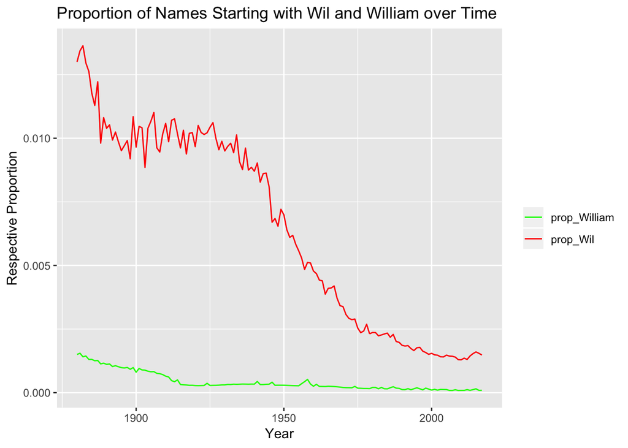

```
##   prop_William
## 1   0.01112306
```

```
##   prop_William
## 1  0.009239582
```

```
##    prop_Wil
## 1 0.1478333
```

Show what regular expression you used to find your name in the dataset: “^Will[iye]+am”

How popular is your name now compared to when you were born? 0.00924% of names recorded in 2017 were william whereas 0.0111% of names recorded in 1997, the year I was born, were William.

How popular is your name now relative to the other names that start with the same three letters? 0.148% of names recorded in 2017 start with the letters “Wil” whereas 0.00924% of those names are recorded in 2017 are “William”

##Ariel and Rachel regexs

How many versions of the female name “Ariel” were there in 1973? 1988? 1990?

```
## # A tibble: 3 x 5
##    year sex   name        n       prop
##   <dbl> <chr> <chr>   <int>      <dbl>
## 1  1973 F     Ariel      43 0.0000277
## 2  1973 F     Arielle     9 0.00000579
## 3  1973 M     Ariel     106 0.0000657
```

In this dataset, there were 2 versions of the female name Ariel in 1973.

```
## # A tibble: 16 x 5
##     year sex   name         n       prop
##    <dbl> <chr> <chr>    <int>      <dbl>
##  1  1988 F     Ariel      910 0.000473
##  2  1988 F     Arielle    654 0.000340
##  3  1988 F     Aerial      57 0.0000296
##  4  1988 F     Ariell      17 0.00000884
##  5  1988 F     Aeriel      15 0.0000078
##  6  1988 F     Arial       12 0.00000624
##  7  1988 F     Aireal      10 0.0000052
##  8  1988 F     Ariele      10 0.0000052
##  9  1988 F     Arriel      10 0.0000052
## 10  1988 F     Areil        9 0.00000468
## 11  1988 F     Arieal       9 0.00000468
## 12  1988 F     Areal        8 0.00000416
## 13  1988 F     Arrielle     6 0.00000312
## 14  1988 F     Aariel       5 0.0000026
## 15  1988 M     Ariel      343 0.000171
## 16  1988 M     Arel         7 0.0000035
```

```
## # A tibble: 25 x 5
##     year sex   name        n      prop
##    <dbl> <chr> <chr>   <int>     <dbl>
##  1  1990 F     Ariel    3606 0.00176
##  2  1990 F     Arielle  1569 0.000764
##  3  1990 F     Aerial     84 0.0000409
##  4  1990 F     Ariell     69 0.0000336
##  5  1990 F     Ariele     47 0.0000229
##  6  1990 F     Aeriel     46 0.0000224
##  7  1990 F     Arial      45 0.0000219
##  8  1990 F     Areil      26 0.0000127
##  9  1990 F     Airel      23 0.0000112
## 10  1990 F     Arriel     23 0.0000112
## # ... with 15 more rows
```

By 1990 in the dataset, there are 22 recorded variations on the name “Ariel” for female babies.

How many versions for the female name “Rachel” for those years?

```
## # A tibble: 7 x 5
##    year sex   name        n       prop
##   <dbl> <chr> <chr>   <int>      <dbl>
## 1  1973 F     Rachel   6106 0.00393
## 2  1973 F     Rachael   972 0.000625
## 3  1973 F     Racheal   150 0.0000965
## 4  1973 F     Rachal     24 0.0000154
## 5  1973 F     Raechel    17 0.0000109
## 6  1973 F     Raychel     8 0.00000515
## 7  1973 M     Rachel     21 0.0000130
```

In 1973, there were 6 variations on “Rachel” for the female babies in the dataset.

```
## # A tibble: 9 x 5
##    year sex   name        n       prop
##   <dbl> <chr> <chr>   <int>      <dbl>
## 1  1988 F     Rachel  15344 0.00798
## 2  1988 F     Rachael  2830 0.00147
## 3  1988 F     Racheal   360 0.000187
## 4  1988 F     Raechel    87 0.0000452
## 5  1988 F     Rachal     54 0.0000281
## 6  1988 F     Raychel    45 0.0000234
## 7  1988 F     Raechal     8 0.00000416
## 8  1988 M     Rachel     62 0.0000310
## 9  1988 M     Rachael     9 0.0000045
```

1988 shows one more variation for the female babies named “Rachel”, with 7 total variations in the dataset.

```
## # A tibble: 9 x 5
##    year sex   name        n       prop
##   <dbl> <chr> <chr>   <int>      <dbl>
## 1  1990 F     Rachel  15705 0.00765
## 2  1990 F     Rachael  3028 0.00147
## 3  1990 F     Racheal   354 0.000172
## 4  1990 F     Raechel    84 0.0000409
## 5  1990 F     Rachal     51 0.0000248
## 6  1990 F     Raychel    51 0.0000248
## 7  1990 F     Raechal     8 0.00000389
## 8  1990 M     Rachel     40 0.0000186
## 9  1990 M     Rachael     7 0.00000325
```

Again, 1990 shows female babies with 7 variations on the name “Rachel”.

What are the chances a girl born in 1973 would be named either Rachel or Ariel (including various versions)? In 1988? In 1990? In 2017?

1973:

```
## # A tibble: 6 x 5
##    year sex   name        n      prop
##   <dbl> <chr> <chr>   <int>     <dbl>
## 1  1973 F     Rachel   6106 0.00393
## 2  1973 F     Rachael   972 0.000625
## 3  1973 F     Racheal   150 0.0000965
## 4  1973 F     Ariel      43 0.0000277
## 5  1973 F     Rachal     24 0.0000154
## 6  1973 F     Raechel    17 0.0000109
```

```
## [1] 0.00471611
```

Thus, there is a 0.0047 chance that a baby girl born in 1973 will be named “Ariel”, “Rachel”, or variations.

1988:

```
## [1] 0.01064194
```

Thus, there is a 0.011 chance of female being named “Ariel”, “Rachel”, or their variations in 1988.

1990:

```
## [1] 0.01214041
```

Thus, there is a 0.012 chance of a girl being named “Ariel”, “Rachel”, or a variation on those names in 1990.

2017:

```
## [1] 0.00262041
```

Therefore, there is a 0.0026 chance of a baby girl being named “Rachel”, “Ariel”, or a variation in 2017.

##The Little Mermaid Effect

###What was the change in proportion in female Ariel baby names? Considering all the changes in female names starting with a vowel from 1988 to 1990, what percentile is the change in Ariel names?

```
## # A tibble: 6 x 10
##   year.x sex.x name  n_1988 prop_1988 year.y sex.y n_1990 prop_1990
##    <dbl> <chr> <chr>  <int>     <dbl>  <dbl> <chr>  <int>     <dbl>
## 1   1988 F     Alys…   7137  0.00371    1990 F      11262   0.00548
## 2   1988 F     Ariel    910  0.000473   1990 F       3606   0.00176
## 3   1988 F     Emily  15870  0.00825    1990 F      19363   0.00943
## 4   1988 F     Oliv…   2138  0.00111    1990 F       4625   0.00225
## 5   1988 F     Alex…   2902  0.00151    1990 F       5256   0.00256
## 6   1988 F     Abig…   2374  0.00123    1990 F       3718   0.00181
## # ... with 1 more variable: change_prop <dbl>
```

```
## [1] 0.00178573
```

The change in proportion of of female baby names that are of Ariel-type spellings between 1988 and 1990 is +0.00178573. By filtering two tibbles for baby names that started with vowels in 1988 and 1990, respectively, and then by merging the two (removing an NA rows), I was able to create a new data frame in which, I could calculate changes in proportion for all the names. This was done using mutate and taking the difference in proportions of names. After sorting the tibble in ascending order my the change in proportion, it was possible to answer the latter of the two questions: what percentile is the change in Ariel names? The largest change in proportion between 1988 and 1990 was for the name Alyssa and had a change in proportion of +0.00177086. However, after adding up all the changes in proportion for the variations spellings of Ariel, we got a larger change in proportion. For this reason, the change in Ariel names is in the 100th percentile.

###Graphing the change in proportion

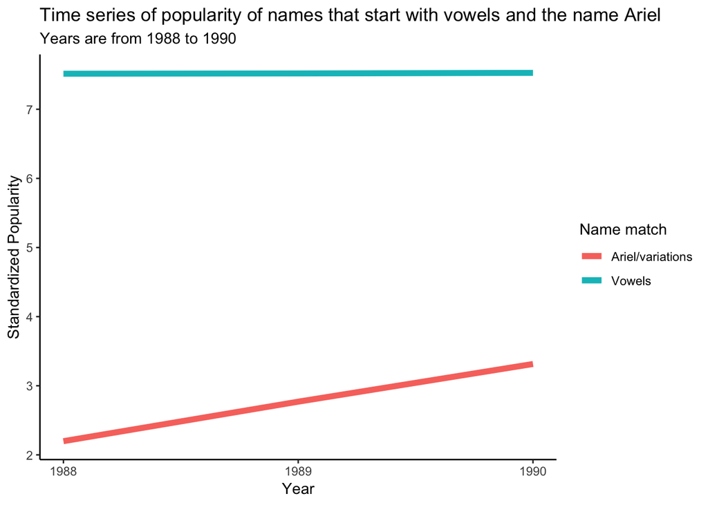

The plot above is a time series, which demonstrates the relative popularity of certain names in the babynames dataset. The years observed in particular were 1988-1990, which is related to the release of the movie “The Little Mermaid”. The blue line depicts the change in proportion of female names that begin with a vowel over this time period, whereas the red line shows the relatively change in proportion of “Ariel” and it’s variations. Because of the nature of the dataset, to see the changes more clearly, the popularity proportion of these names were standardized by multiplicative and logarithmic scaling. Thus, the change in popularity is standardized, and it’s clearly observed there is a stronger rise in popularity in the name Ariel over this time period.

From the plot above, it’s clear that the name “Ariel” and it’s variations rose in popularity in the throughout the years 1988 to 1990, as observed in this dataset. Looking at the base comparison, which is the female names which start with a vowel, it’s clear the popularity proportion remained nearly constant throughout the target years. Due to this constancy, the relative change in popularity of the name Ariel is significant, and substantively large. Therefore, it’s reasonable to conclude from this visualisation and analysis that “The Little Mermaid” did indeed have a relatively large effect on the popularity of the name “Ariel”, as reflected in this dataset.

##Who Did What

###Rachael

For this lab, I first completed the individual portion, and plotted the time series of my names popularity over time. This required me to find variations on the spelling of my name, and develop a regular expression. Further along, I created plots for all the sections of the lab, and provided my code for the first two plots, and first computation section. In addition, I wrote the analysis for the Little Mermaid plot. Finally, I helped my group troubleshoot their code and work through the logics of the last several questions.

###Manasi

###Brady

###William

The first part of the lab tasked us with individually determining how the proportion of various ways of spelling our name changed with time. Additionally, how the proportion of names starting with the first three letters of our names changed over time. I chose to implement this manually as opposed to looking at the proportion column of the babynames tibble. I began by creating a tibble which was a filtered version of the babynames tibble based on those names that started with “Wil”. I then used parse_date to change the date column to type date. Then, I created another tibble which took the filtered tible based on the first three letters of my name, grouped them by year, and counted so that I could have a total number of names starting with “Wil” by year. I also needed a total number of names by year so that I could derive proportions so I created one. I then merged the tibbles of total number of names starting with “Wil” and total number of names by year based on the date key. With mutate, I created a prop_Wil column which was the proportion of names starting with “Wil” over time. I followed a similar logic and added a column of total number of William-type spellings into this aggregated tibble so that I could also come up with a proportion of total number of William’s by year. I used the regex: “^Will[iye]+am”. After I had everything I needed in the same tibble, I used ggplot to show how the respective proportions changed over time. Because I was using to geom_line function calls, I ran into some difficultly figuring out how to label the key, howver, find a solution which can be viewed in my code implemented above. To end the individual section, I answered the respective questions. How popular is your name now compared to when you were born? To answer this question, I filtered my aggregated tibble by date twice, once for my birth year of 1997 and once for the most recent year in the data of 2017. I muliplied the prop_William column in both of the aforementioned filtered data frames by 100 to get the answers in a percent and reported them to show what the percentage change in proportion of William names was between 1997 and 2017. How popular is your name now relative to the other names that start with the same three letters? To answer this, I, like above, computed a percentage for the proportion of names starting with “Will” in 2017 and compared that with the percentage for the proportion of names speled like “William” in 2017.

For the group part, I contributed by answering the following questions. What was the change in proportion in female Ariel baby names? Considering all the changes in female names starting with a vowel from 1988 to 1990, what percentile is the change in Ariel names? To answer the first question, I began by creating a new tibble which filtered the babynames tibble for female names starting with vowels in 1988. I created another tibble which filtered for female names starting with vowels in 1990. I joined these two tibbles and dropped the NA values. Then, using the mutate function, I came up with a change in proportion column which was calculated by taking the difference between the proportion of a respective name in 1990 and the proportion of that same name in 1988. I arranged the tibble based on this newly created column in ascending order. Then, from this tibble, I created a new tibble which filtered for names that followed the appropriate regex. I summed the change in proportion columns of this new tibble to get the total change in proportion for Ariel-type spellings between 1988 and 1990. I got a value of 0.00178573. I then compared this value to the preceding tibble which sorted the change in proportion of female names starting with vowels between 1988 and 1990 by ascending order. The largest change in proporiton was 0.00177086 which was smaller than the previously computed value so I concluded that the change in Ariel names was in the 100th percentile.